# Seasonal Agriculture Performance Analysis

**VOIS AICTE Batch1 2026-2027 — Major Project**

**Dataset:** `seasonal_agriculture_performance_dataset.csv` (4,000 farm records)

**Objective:** Analyze how agricultural performance — yield, resource usage, and profitability — changes across the three Indian cropping seasons (Kharif, Rabi and Zaid), and identify patterns that can support better seasonal planning.

This notebook was built and run in Google Colab. The workflow follows: data loading → cleaning → exploration → seasonal comparison → correlation analysis → insights → recommendations.

## 1. Import Libraries

```python
import pandas as pd
import numpy as np
import matplotlib.pyplot as plt
import seaborn as sns

# display settings
pd.set_option('display.max_columns', 30)
pd.set_option('display.width', 150)
sns.set_style('white')
plt.rcParams['axes.spines.top'] = False
plt.rcParams['axes.spines.right'] = False
%matplotlib inline
```

## 2. Load the Dataset

If you're running this in Colab, upload `seasonal_agriculture_performance_dataset.csv` first (via the file upload icon on the left, or `from google.colab import files; files.upload()`).

One thing worth flagging here — even though the file has a `.csv` extension, it's actually saved in Excel's internal format (probably exported from Excel/Sheets without changing the file type). `pd.read_csv()` throws a parsing error on it, so it needs to be read with `read_excel` instead.

```python
# NOTE: despite the .csv extension, the file is Excel-formatted internally,
# so read_csv() fails here. read_excel() handles it correctly.
df = pd.read_excel('seasonal_agriculture_performance_dataset.csv', engine='openpyxl')

print(df.shape)
df.head()
```

```
(4000, 28)
```

|  | Farm_ID | State | District | Crop | Season | Farm_Area_Hectares | Rainfall_mm | Avg_Temperature_C | Humidity_pct | Sunlight_Hours_Day | Soil_pH | Soil_Moisture_pct | Nitrogen_kg_ha | Phosphorus_kg_ha | Potassium_kg_ha | Irrigation_Method | Fertilizer_kg_ha | Pesticide_Litre_ha | Seed_Quality_Score | Yield_Tonnes_Ha | Production_Tonnes | Market_Price_INR_Tonne | Total_Cost_INR | Revenue_INR | Profit_INR | Water_Used_m3 | Water_Efficiency_t_per_1000m3 | Disease_Pest_Risk_pct |
| --- | --- | --- | --- | --- | --- | --- | --- | --- | --- | --- | --- | --- | --- | --- | --- | --- | --- | --- | --- | --- | --- | --- | --- | --- | --- | --- | --- | --- |
| 0 | SF10001 | Andhra Pradesh | Rajkot | Wheat | Kharif | 0.53 | 486.4 | 24.3 | 69.1 | 5.8 | 7.14 | 32.8 | 75.8 | 61.3 | 91.0 | Drip | 242.7 | 4.33 | 0.76 | 2.46 | 1.30 | 23700 | 42662 | 30810 | -11852 | 237 | 5.485 | 55.3 |
| 1 | SF10002 | Maharashtra | Nalgonda | Maize | Kharif | 6.53 | 855.4 | 25.7 | 78.4 | 5.1 | 5.20 | 32.0 | 82.1 | 35.4 | 121.8 | Flood | 271.4 | 6.86 | 0.94 | 0.30 | 1.96 | 20613 | 492351 | 40401 | -451950 | 4953 | 0.396 | 49.9 |
| 2 | SF10003 | Telangana | Warangal | Pulses | Rabi | 4.86 | 455.6 | 23.9 | 56.4 | 10.3 | 5.82 | 8.1 | 118.5 | 51.5 | 117.9 | Drip | 162.6 | 6.08 | 0.98 | 0.52 | 2.53 | 75283 | 315210 | 190466 | -124744 | 1275 | 1.984 | 33.7 |
| 3 | SF10004 | Telangana | Indore | Rice | Kharif | 4.50 | 753.2 | 29.7 | 65.2 | 6.3 | 5.98 | 23.7 | 138.6 | 55.6 | 115.5 | Rainfed | 182.2 | 6.39 | 0.74 | 1.84 | 8.28 | 24244 | 296444 | 200740 | -95704 | 3834 | 2.160 | 50.6 |
| 4 | SF10005 | Karnataka | Ludhiana | Maize | Zaid | 4.21 | 101.6 | 34.1 | 55.2 | 6.5 | 6.90 | 29.3 | 124.1 | 69.0 | 121.4 | Flood | 244.9 | 7.61 | 0.90 | 2.21 | 9.30 | 20818 | 337959 | 193607 | -144352 | 3287 | 2.829 | 32.3 |

## 3. Initial Exploration

```python
df.info()
```

```
<class 'pandas.DataFrame'>
RangeIndex: 4000 entries, 0 to 3999
Data columns (total 28 columns):
 #   Column                         Non-Null Count  Dtype
---  ------                         --------------  -----
 0   Farm_ID                        4000 non-null   str
 1   State                          4000 non-null   str
 2   District                       4000 non-null   str
 3   Crop                           4000 non-null   str
 4   Season                         4000 non-null   str
 5   Farm_Area_Hectares             4000 non-null   float64
 6   Rainfall_mm                    3952 non-null   float64
 7   Avg_Temperature_C              4000 non-null   float64
 8   Humidity_pct                   4000 non-null   float64
 9   Sunlight_Hours_Day             4000 non-null   float64
```

[output cut: 20 more lines]

```python
df.describe().T
```

|  | count | mean | std | min | 25% | 50% | 75% | max |
| --- | --- | --- | --- | --- | --- | --- | --- | --- |
| Farm_Area_Hectares | 4000.0 | 7.888265 | 4.223764 | 0.500 | 4.260 | 7.8950 | 11.65000 | 15.00 |
| Rainfall_mm | 3952.0 | 601.152657 | 288.925025 | 80.000 | 370.200 | 582.0000 | 834.95000 | 1395.20 |
| Avg_Temperature_C | 4000.0 | 26.818900 | 3.818180 | 16.200 | 23.900 | 26.9000 | 29.60000 | 39.70 |
| Humidity_pct | 4000.0 | 63.210500 | 11.960834 | 25.000 | 54.775 | 63.0000 | 71.90000 | 95.00 |
| Sunlight_Hours_Day | 4000.0 | 7.323050 | 1.121186 | 3.500 | 6.600 | 7.3000 | 8.10000 | 11.00 |
| Soil_pH | 4000.0 | 6.701010 | 0.641461 | 5.200 | 6.260 | 6.6900 | 7.14000 | 8.40 |
| Soil_Moisture_pct | 3960.0 | 26.508232 | 6.712484 | 8.000 | 21.700 | 26.4000 | 31.30000 | 47.00 |
| Nitrogen_kg_ha | 4000.0 | 120.250825 | 31.216452 | 40.000 | 98.500 | 120.1000 | 141.22500 | 220.00 |
| Phosphorus_kg_ha | 4000.0 | 57.781850 | 17.015074 | 15.000 | 46.200 | 57.5000 | 69.40000 | 120.00 |
| Potassium_kg_ha | 4000.0 | 104.760050 | 27.742681 | 30.000 | 86.200 | 105.1000 | 123.60000 | 200.00 |
| Fertilizer_kg_ha | 4000.0 | 186.036000 | 60.260583 | 40.000 | 143.975 | 186.2500 | 227.20000 | 400.00 |
| Pesticide_Litre_ha | 4000.0 | 5.070935 | 1.978879 | 0.500 | 3.690 | 5.1200 | 6.40000 | 12.08 |
| Seed_Quality_Score | 4000.0 | 0.826138 | 0.101747 | 0.650 | 0.740 | 0.8300 | 0.91000 | 1.00 |
| Yield_Tonnes_Ha | 3968.0 | 5.270595 | 13.361398 | 0.300 | 1.050 | 1.7400 | 2.84000 | 101.44 |
| Production_Tonnes | 4000.0 | 43.246210 | 126.880521 | 0.150 | 5.020 | 11.7700 | 24.35500 | 1424.40 |
| Market_Price_INR_Tonne | 4000.0 | 44714.166250 | 30266.161922 | 2594.000 | 21429.250 | 25913.0000 | 68279.00000 | 131240.00 |
| Total_Cost_INR | 4000.0 | 526303.583000 | 294419.140911 | 26826.000 | 274577.500 | 519082.5000 | 761996.50000 | 1349990.00 |
| Revenue_INR | 4000.0 | 637860.048000 | 636974.710054 | 6107.000 | 207517.250 | 456830.5000 | 836874.75000 | 5080900.00 |
| Profit_INR | 4000.0 | 111556.465000 | 545081.890509 | -1019223.000 | -148731.750 | 3673.0000 | 216187.75000 | 4345421.00 |
| Water_Used_m3 | 4000.0 | 6045.570250 | 5572.944306 | 128.000 | 2268.750 | 4435.0000 | 7829.75000 | 40902.00 |
| Water_Efficiency_t_per_1000m3 | 4000.0 | 5.385214 | 8.838101 | 0.135 | 1.661 | 2.9375 | 5.15025 | 79.80 |
| Disease_Pest_Risk_pct | 4000.0 | 46.365875 | 12.424417 | 5.000 | 37.300 | 46.4000 | 54.90000 | 88.90 |

```python
for col in ['Season', 'Crop', 'State', 'Irrigation_Method']:
    print(f"--- {col} ---")
    print(df[col].value_counts())
    print()
```

```
--- Season ---
Season
Kharif    1779
Rabi      1627
Zaid       594
Name: count, dtype: int64

--- Crop ---
Crop
Rice         690
Wheat        614
Maize        551
Cotton       508
Pulses       496
Groundnut    424
Chilli       412
Sugarcane    305
Name: count, dtype: int64

--- State ---
State
Andhra Pradesh    529
Telangana         516
Maharashtra       512
Madhya Pradesh    497
Karnataka         489
Gujarat           488
Tamil Nadu        485
Punjab            484
Name: count, dtype: int64

--- Irrigation_Method ---
Irrigation_Method
Flood        1310
Rainfed      1041
Drip          915
Sprinkler     734
Name: count, dtype: int64
```

**Quick read on the dataset:**

- 4,000 farms spread across 3 seasons — Kharif has the most records (1,779), followed by Rabi (1,627) and Zaid (594). This roughly matches how Indian cropping calendars actually work — Zaid is a short summer season squeezed between the two main ones, so fewer farms plant during it.
- 8 crops, 8 states, 10 districts, 4 irrigation methods.
- No obvious data entry issues in the categorical columns.

## 4. Data Cleaning

```python
df.isnull().sum()[df.isnull().sum() > 0]
```

```
Rainfall_mm          48
Soil_Moisture_pct    40
Yield_Tonnes_Ha      32
dtype: int64
```

Three columns have missing values — `Rainfall_mm`, `Soil_Moisture_pct` and `Yield_Tonnes_Ha`. All three are small (1-1.2% of rows), so dropping them isn't necessary. Instead of filling with a single global median (which would blur seasonal differences), missing rainfall/soil moisture values are filled with the **season median**, and missing yield values are filled with the **crop + season median** since yield varies a lot by crop.

```python
df['Rainfall_mm'] = df.groupby('Season')['Rainfall_mm'].transform(lambda x: x.fillna(x.median()))
df['Soil_Moisture_pct'] = df.groupby('Season')['Soil_Moisture_pct'].transform(lambda x: x.fillna(x.median()))
df['Yield_Tonnes_Ha'] = df.groupby(['Crop', 'Season'])['Yield_Tonnes_Ha'].transform(lambda x: x.fillna(x.median()))

print("Remaining missing values:", df.isnull().sum().sum())
print("Duplicate Farm IDs:", df['Farm_ID'].duplicated().sum())
```

```
Remaining missing values: 0
Duplicate Farm IDs: 0
```

**Checking the yield outliers.** The summary stats earlier showed `Yield_Tonnes_Ha` going up to ~101 t/ha, which looks suspicious next to a 75th percentile of just 2.84. Before treating it as an error, it's worth checking what crop those rows belong to.

```python
df.nlargest(10, 'Yield_Tonnes_Ha')[['Crop', 'Season', 'Yield_Tonnes_Ha', 'Production_Tonnes', 'Farm_Area_Hectares']]
```

|  | Crop | Season | Yield_Tonnes_Ha | Production_Tonnes | Farm_Area_Hectares |
| --- | --- | --- | --- | --- | --- |
| 1715 | Sugarcane | Kharif | 101.44 | 641.10 | 6.32 |
| 3423 | Sugarcane | Kharif | 95.79 | 1424.40 | 14.87 |
| 3525 | Sugarcane | Rabi | 93.13 | 648.18 | 6.96 |
| 1464 | Sugarcane | Kharif | 91.98 | 703.65 | 7.65 |
| 3523 | Sugarcane | Kharif | 91.46 | 75.00 | 0.82 |
| 2782 | Sugarcane | Rabi | 91.32 | 522.35 | 5.72 |
| 644 | Sugarcane | Kharif | 89.34 | 668.26 | 7.48 |
| 2847 | Sugarcane | Kharif | 87.76 | 672.24 | 7.66 |
| 357 | Sugarcane | Rabi | 84.75 | 1249.21 | 14.74 |
| 1178 | Sugarcane | Kharif | 83.79 | 534.58 | 6.38 |

All ten highest-yield rows are **Sugarcane**, which genuinely yields 60-100+ t/ha in real farming — it's a heavy, water-dense crop unlike grains such as wheat or rice. So these aren't data errors, just a different crop scale, and they've been left in the dataset.

**A quick geography check.** Before doing any state-wise comparison, it's worth checking whether `State` and `District` are consistently paired (e.g. does "Warangal" always show up under "Telangana"?).

```python
pd.crosstab(df['State'], df['District']).iloc[:, :4]
```

| District State | Erode | Guntur | Indore | Krishna |
| --- | --- | --- | --- | --- |
| Andhra Pradesh | 45 | 49 | 47 | 54 |
| Gujarat | 61 | 58 | 34 | 35 |
| Karnataka | 39 | 44 | 42 | 54 |
| Madhya Pradesh | 39 | 51 | 48 | 54 |
| Maharashtra | 47 | 53 | 51 | 59 |
| Punjab | 53 | 46 | 45 | 56 |
| Tamil Nadu | 51 | 52 | 54 | 39 |
| Telangana | 68 | 37 | 71 | 42 |

Every district appears under every state in roughly similar counts, which means `State` and `District` were generated independently rather than reflecting real geography (e.g. "Ludhiana", a Punjab city, shows up under Karnataka and Tamil Nadu too). Because of this, state/district are treated purely as categorical grouping labels in this analysis, not as real regional indicators — no geographic conclusions are drawn from them.

## 5. How Do Seasons Differ? — Environmental Conditions

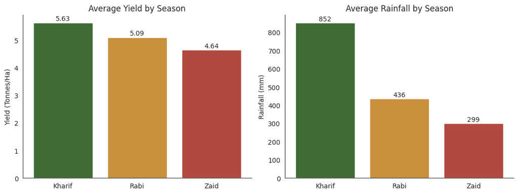

```python
season_order = ['Kharif', 'Rabi', 'Zaid']
palette = {'Kharif': '#3F6B35', 'Rabi': '#C98F3B', 'Zaid': '#B14A3E'}

fig, axes = plt.subplots(1, 2, figsize=(11, 4.2))

g = df.groupby('Season')['Yield_Tonnes_Ha'].mean().reindex(season_order)
axes[0].bar(g.index, g.values, color=[palette[s] for s in g.index])
axes[0].set_title('Average Yield by Season')
axes[0].set_ylabel('Yield (Tonnes/Ha)')
for i, v in enumerate(g.values):
    axes[0].text(i, v + 0.08, f'{v:.2f}', ha='center')

r = df.groupby('Season')['Rainfall_mm'].mean().reindex(season_order)
axes[1].bar(r.index, r.values, color=[palette[s] for s in r.index])
axes[1].set_title('Average Rainfall by Season')
axes[1].set_ylabel('Rainfall (mm)')
for i, v in enumerate(r.values):
    axes[1].text(i, v + 10, f'{v:.0f}', ha='center')

plt.tight_layout()
plt.savefig('chart1_yield_rainfall.png', dpi=200, bbox_inches='tight')
plt.show()
```

Kharif (the monsoon season, June-October) gets nearly double the rainfall of Rabi and almost triple that of Zaid — and it shows in the yield numbers too. Kharif farms average **5.63 t/ha**, about 21% higher than Zaid's **4.64 t/ha**. Rabi sits in between at **5.09 t/ha**, which makes sense since it's a winter season that relies more on residual soil moisture and irrigation than direct rainfall.

```python
df.groupby('Season')[['Avg_Temperature_C', 'Humidity_pct', 'Soil_Moisture_pct']].mean().reindex(season_order).round(2)
```

| Season | Avg_Temperature_C | Humidity_pct | Soil_Moisture_pct |
| --- | --- | --- | --- |
| Kharif | 28.45 | 71.81 | 31.20 |
| Rabi | 23.49 | 57.89 | 24.05 |
| Zaid | 31.04 | 52.01 | 19.17 |

Zaid is the hottest season on average (~31°C) with the lowest humidity and soil moisture — a tough combination for most crops, which lines up with it having the lowest yield.

## 6. Profitability Across Seasons

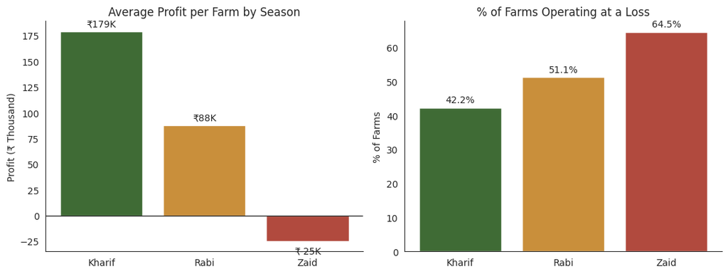

```python
fig, axes = plt.subplots(1, 2, figsize=(11, 4.2))

p = df.groupby('Season')['Profit_INR'].mean().reindex(season_order)
axes[0].bar(p.index, p.values / 1000, color=[palette[s] for s in p.index])
axes[0].axhline(0, color='black', linewidth=0.8)
axes[0].set_title('Average Profit per Farm by Season')
axes[0].set_ylabel('Profit (₹ Thousand)')
for i, v in enumerate(p.values):
    axes[0].text(i, v/1000 + (5 if v >= 0 else -12), f'₹{v/1000:.0f}K', ha='center')

loss_pct = df.groupby('Season').apply(lambda x: (x['Profit_INR'] < 0).mean() * 100).reindex(season_order)
axes[1].bar(loss_pct.index, loss_pct.values, color=[palette[s] for s in loss_pct.index])
axes[1].set_title('% of Farms Operating at a Loss')
axes[1].set_ylabel('% of Farms')
for i, v in enumerate(loss_pct.values):
    axes[1].text(i, v + 1.5, f'{v:.1f}%', ha='center')

plt.tight_layout()
plt.savefig('chart2_profitability.png', dpi=200, bbox_inches='tight')
plt.show()
```

This is probably the most important finding in the whole analysis. Even though average cost per farm is fairly similar across seasons (roughly ₹5.1-5.4 lakh), the outcome is very different:

- **Kharif** farms average a profit of **₹1.79 lakh**, and only 42% run at a loss.
- **Rabi** farms average just **₹88K** profit, with just over half (51%) running at a loss.
- **Zaid** farms average an outright **loss of ₹25K**, and nearly two-thirds (64.5%) of Zaid farms lose money.

So the season with the least rainfall and highest heat isn't just lower-yielding — it's financially the riskiest one to farm in, under this dataset.

## 7. What's Actually Driving Yield and Profit? — Correlation Check

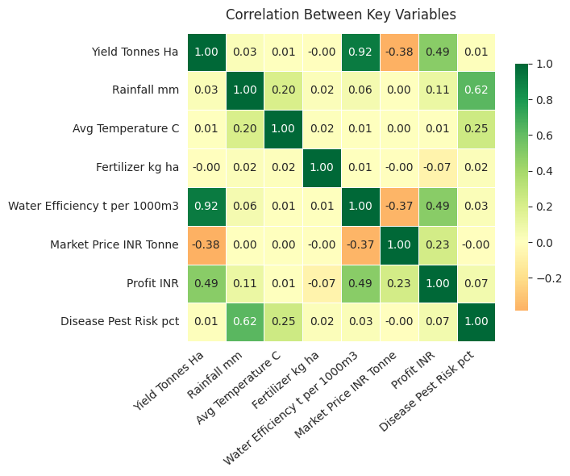

```python
cols = ['Yield_Tonnes_Ha', 'Rainfall_mm', 'Avg_Temperature_C', 'Fertilizer_kg_ha',
        'Water_Efficiency_t_per_1000m3', 'Market_Price_INR_Tonne', 'Profit_INR', 'Disease_Pest_Risk_pct']
corr = df[cols].corr()

fig, ax = plt.subplots(figsize=(7.5, 6))
sns.heatmap(corr, annot=True, fmt='.2f', cmap='RdYlGn', center=0, square=True,
            cbar_kws={'shrink': 0.8}, linewidths=0.5, linecolor='white', ax=ax,
            xticklabels=[c.replace('_', ' ') for c in cols], yticklabels=[c.replace('_', ' ') for c in cols])
plt.xticks(rotation=40, ha='right')
ax.set_title('Correlation Between Key Variables', pad=12)
plt.tight_layout()
plt.savefig('chart3_correlation.png', dpi=200, bbox_inches='tight')
plt.show()
```

A few things stand out here that weren't obvious just from the seasonal averages:

- **Water efficiency correlates very strongly with yield (r = 0.92)** — basically, farms that convert water into crop tonnage efficiently are the ones getting good yields, more so than any single environmental factor.
- **Fertilizer use has almost zero correlation with yield (r ≈ 0.00)**. This was a bit surprising — more fertilizer isn't translating into more yield in this dataset, which could mean farms are already at a saturation point, or fertilizer isn't the limiting factor here.
- **Market price is negatively correlated with yield (r = -0.38)**. This makes sense once you think about it: high-yield crops like Sugarcane sell at a lower price per tonne than low-yield, high-value crops like Chilli — so raw yield alone doesn't tell you about profitability.
- **Rainfall correlates with disease/pest risk (r = 0.62)** — wetter conditions bring more pest and disease pressure, which is a real agronomic pattern (and probably explains why Kharif has the highest risk score despite also having the highest yield, see below).

## 8. Irrigation Method & Disease/Pest Risk by Season

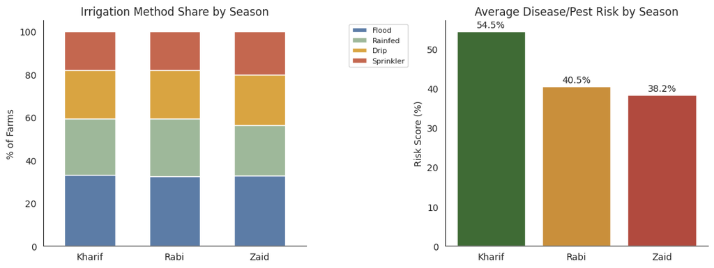

```python
fig, axes = plt.subplots(1, 2, figsize=(11, 4.2))

irr = pd.crosstab(df['Season'], df['Irrigation_Method'], normalize='index').reindex(season_order) * 100
irr = irr[['Flood', 'Rainfed', 'Drip', 'Sprinkler']]
irr.plot(kind='bar', stacked=True, ax=axes[0], color=['#5C7CA6', '#9EB89A', '#D9A441', '#C4674F'], width=0.6)
axes[0].set_title('Irrigation Method Share by Season')
axes[0].set_ylabel('% of Farms')
axes[0].set_xlabel('')
axes[0].tick_params(axis='x', rotation=0)
axes[0].legend(fontsize=8, loc='upper right', bbox_to_anchor=(1.4, 1))

risk = df.groupby('Season')['Disease_Pest_Risk_pct'].mean().reindex(season_order)
axes[1].bar(risk.index, risk.values, color=[palette[s] for s in risk.index])
axes[1].set_title('Average Disease/Pest Risk by Season')
axes[1].set_ylabel('Risk Score (%)')
for i, v in enumerate(risk.values):
    axes[1].text(i, v + 1, f'{v:.1f}%', ha='center')

plt.tight_layout()
plt.savefig('chart4_irrigation_risk.png', dpi=200, bbox_inches='tight')
plt.show()
```

Interestingly, the irrigation method mix barely changes across seasons — Flood stays the most common method (~33%) in all three, followed by Rainfed, Drip, and Sprinkler in roughly the same proportions. So farmers don't appear to be switching irrigation strategy by season in this data, which itself is a bit of a finding (it's not a variable that explains the seasonal yield/profit gap).

Disease/pest risk, on the other hand, does shift clearly by season — Kharif is highest at 54.5%, consistent with the rainfall-risk correlation seen earlier, while Rabi and Zaid sit lower at ~40% and ~38%.

## 9. Crop Performance Within Each Season

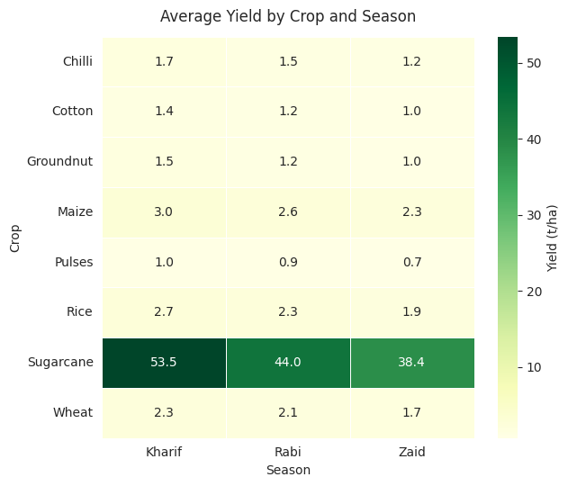

```python
pivot = df.pivot_table(values='Yield_Tonnes_Ha', index='Crop', columns='Season', aggfunc='mean')[season_order]

fig, ax = plt.subplots(figsize=(6.5, 5.5))
sns.heatmap(pivot, annot=True, fmt='.1f', cmap='YlGn', linewidths=0.5, linecolor='white',
            ax=ax, cbar_kws={'label': 'Yield (t/ha)'})
ax.set_title('Average Yield by Crop and Season', pad=12)
plt.tight_layout()
plt.savefig('chart5_crop_season_heatmap.png', dpi=200, bbox_inches='tight')
plt.show()
```

Sugarcane dominates the yield scale regardless of season (it's just a bulkier crop), but relative to itself, most crops still follow the overall pattern of doing better in Kharif than Zaid — Rice and Maize in particular show a noticeable drop from Kharif to Zaid, which tracks with them being more water-dependent crops.

## 10. Key Insights

1. **Kharif is the strongest season overall** — highest average yield (5.63 t/ha), highest average profit (₹1.79 lakh/farm), and the lowest share of loss-making farms (42%).
2. **Zaid is the weakest and riskiest season** — lowest yield (4.64 t/ha), an average loss of ₹25K/farm, and 64.5% of farms losing money. High heat and low rainfall/soil moisture during Zaid appear to be the main drag.
3. **Water efficiency, not fertilizer, is the strongest predictor of yield** (r = 0.92 vs r ≈ 0.00 for fertilizer). Fertilizer input doesn't seem to be the bottleneck here.
4. **Yield and market price move in opposite directions** (r = -0.38) — high-yield bulk crops (Sugarcane) fetch lower per-tonne prices than low-yield, higher-value crops (Chilli, Cotton), so yield alone is a poor proxy for profitability.
5. **Rainfall drives up disease/pest risk** (r = 0.62), which is likely why Kharif — despite being the best-performing season — also carries the highest average pest/disease risk score (54.5%).
6. **Irrigation method choice does not vary meaningfully by season** — Flood remains the dominant method (~33% share) across all three seasons, so it isn't a factor explaining the seasonal performance gap.
7. **The State/District fields in this dataset are not geographically consistent** (each district appears across all states in similar proportions), so any regional patterns should be treated as categorical, not real geography.

## 11. Conclusions & Recommendations

Season has a clear, measurable effect on agricultural outcomes in this dataset — not just on yield, but more importantly on profitability and risk. Zaid, in particular, stands out as a season where a majority of farms are currently losing money, which is worth flagging for planning purposes.

**Recommendations:**

- Farmers cultivating in Zaid season may benefit from water-efficient crop choices or drip/sprinkler irrigation, since water efficiency is the strongest yield driver identified here, and Zaid already has the lowest rainfall and soil moisture.
- Given that fertilizer showed almost no relationship with yield, input costs going into fertilizer during low-yield seasons like Zaid could be re-evaluated rather than increased.
- Because Kharif combines the highest yield with the highest disease/pest risk, seasonal pest-management advisories may be more valuable in Kharif than the other two seasons.
- Since raw yield doesn't guarantee profit (given the negative yield-price correlation), season-wise crop selection should weigh expected market price alongside expected yield, not yield alone.
- Future versions of this dataset would benefit from consistent, real State-District geography, so genuine regional seasonal patterns (e.g. differences by agro-climatic zone) could also be studied.